# ANALÍTICA Y CIENCIA DE DATOS PARA NEGOCIOS: DETECCIÓN Y MANEJO DE VALORES FALTANTES (ANALYTICS AND DATA SCIENCE FOR BUSINESS: DETECTION AND HANDLING OF MISSING VALUES)

José Mauricio Gómez Julián

2023-12-10

# A. CASO 1: BOSTON HOUSING

## I. CARGAR BASE DE DATOS

```r
library(mlbench)
data("BostonHousing", package = "mlbench")

original = BostonHousing

#Por defecto, la data "BostonHousing" no contiene NA's, por lo que se introducirán NA aleatoriamente en dos de sus variables

set.seed(100)
BostonHousing[sample(1:nrow(BostonHousing), 40), "rad"] <- NA
BostonHousing[sample(1:nrow(BostonHousing), 40), "ptratio"] <- NA
head(BostonHousing)
```

```
##      crim zn indus chas   nox    rm  age    dis rad tax ptratio      b lstat
## 1 0.00632 18  2.31    0 0.538 6.575 65.2 4.0900   1 296    15.3 396.90  4.98
## 2 0.02731  0  7.07    0 0.469 6.421 78.9 4.9671   2 242    17.8 396.90  9.14
## 3 0.02729  0  7.07    0 0.469 7.185 61.1 4.9671   2 242    17.8 392.83  4.03
## 4 0.03237  0  2.18    0 0.458 6.998 45.8 6.0622  NA 222    18.7 394.63  2.94
## 5 0.06905  0  2.18    0 0.458 7.147 54.2 6.0622   3 222    18.7 396.90  5.33
## 6 0.02985  0  2.18    0 0.458 6.430 58.7 6.0622   3 222    18.7 394.12  5.21
##   medv
## 1 24.0
## 2 21.6
## 3 34.7
## 4 33.4
## 5 36.2
## 6 28.7
```

Puede verse en https://www.kaggle.com/code/prasadperera/the-boston-housing-dataset una descripción completa de la base de datos.

El código que proporcionaste está escrito en el lenguaje de programación R y utiliza algunas funciones y conjuntos de datos del paquete “mlbench”. Aquí está una explicación línea por línea:

1. **library(mlbench)**: Carga la biblioteca “mlbench” en R. Esta biblioteca contiene conjuntos de datos de aprendizaje automático y funciones auxiliares para el análisis de datos.
2. **data(“BostonHousing”, package = “mlbench”)**: Carga el conjunto de datos “BostonHousing” desde el paquete “mlbench”. Este conjunto de datos contiene información sobre viviendas en Boston y se utiliza comúnmente en problemas de regresión.
3. **set.seed(100)**: Establece una semilla para la generación de números aleatorios. Esto se hace para que los resultados sean reproducibles. La semilla “100” es arbitraria y puede cambiarse según sea necesario.
4. **BostonHousing[sample(1:nrow(BostonHousing), 40), “rad”] <- NA**: Aquí se introduce un mecanismo de datos faltantes. La función sample selecciona aleatoriamente 40 filas de la variable (columna) “rad” del conjunto de datos “BostonHousing”, y luego se asignan valores NA (datos faltantes).
5. **BostonHousing[sample(1:nrow(BostonHousing), 40), “ptratio”] <- NA**: Similar a la línea anterior, se seleccionan aleatoriamente 40 filas y se asignan valores NA a la columna “ptratio” de esas filas.
6. **head(BostonHousing)**: Muestra las primeras filas del conjunto de datos “BostonHousing” con las modificaciones realizadas. Esto proporciona una visión rápida de cómo se ven los datos después de la introducción de datos faltantes.

## II. MANEJO DE VALORES FALTANTES

### II.I. ANALIZAR NIVELES DE FALTABILIDAD

```r
library(mice)
```

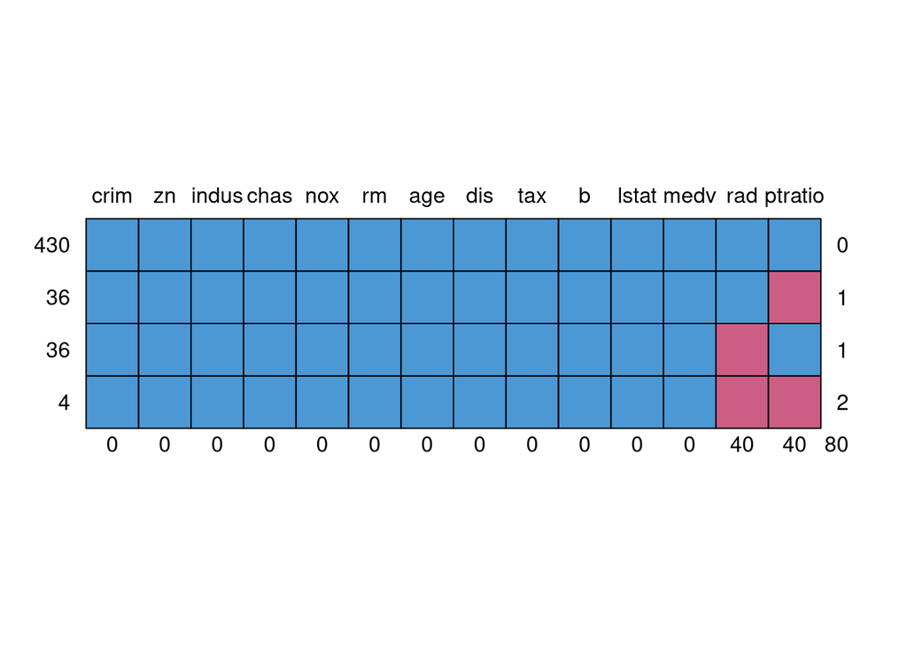

```
##     crim zn indus chas nox rm age dis tax b lstat medv rad ptratio
## 430    1  1     1    1   1  1   1   1   1 1     1    1   1       1  0
## 36     1  1     1    1   1  1   1   1   1 1     1    1   1       0  1
## 36     1  1     1    1   1  1   1   1   1 1     1    1   0       1  1
## 4      1  1     1    1   1  1   1   1   1 1     1    1   0       0  2
##        0  0     0    0   0  0   0   0   0 0     0    0  40      40 80
```

```r
md.pattern(BostonHousing) #la función md.pattern sirve para poder evaluar y contabilizar los registros de valores contenidos en una base de datos, pudiendo así detectar cuando ocurren valores faltantes.
```

```r
# Para determinar la cantidad de NA's por columna, puede usarse la siguiente sintaxis:

sum(is.na(BostonHousing$rad))
```

```
## [1] 40
```

```r
sum(is.na(BostonHousing$ptratio))
```

```
## [1] 40
```

La gráfica resultante se lee de la siguiente manera:

1. La primera fila indica la cantidad de observaciones (de elementos de fila del dataframe analizado) completas del total de observaciones. En este caso, 430 observaciones (número a la izquierda de la fila analizada) de 506 observaciones. El número a la derecha de la fila analizada indica la cantidad de columnas que poseen valores faltantes (que, dado que en esta primera fila se analizan únicamente la cantidad de registros completos).
2. El número a la izquierda de la segunda fila indica la cantidad de valores (de elementos de fila del dataframe analizado) en determinada variable (marcada con un cuadro rojo) que están incompletas (y el número a la derecha de dicha fila equivale a la cantidad de columnas marcadas con un cuadro rojo).
3. El número a la izquierda de la tercera fila indica la cantidad de valores (de elementos de fila del dataframe analizado) en determinada variable (marcada con un cuadro rojo) que están incompletas (y el número a la derecha de dicha fila equivale a la cantidad de columnas marcadas con un cuadro rojo).
4. La cuarta fila indica la cantidad de registros (de elementos de fila del dataframe analizado) que tienen valores faltantes tanto en “rad” como en “ptratio”.

La matriz que arroja la función implementada es equivalente a la tabla gráfica, con la diferencia de que el uso del rojo lo sustituyen por el uso de “0”.

### II.II. BORRADO DE OBSERVACIONES (OMITIR OBSERVACIONES)

Comenzaremos revisando el primer caso o estrategia, que es el “borrado de observaciones”. El código en R para llevar a cabo el borrado de observaciones se basa, dado que este borrado está específicamente vinculado (generalmente) al aprendizaje supervisado, en utilizar el borrado a través de la formación del modelo lineal. A continuación, describiremos el borrado de variables.

En el caso de que haya muchas observaciones en la base de datos y haya registros suficientes en los datos de entrenamiento para representar adecuadamente cada clase que se va a estimar, el borrado de variables es una estrategia válida. Se pueden eliminar o excluir registros de ellas durante la construcción del modelo. Aquellas observaciones o filas que contienen datos faltantes serán omitidas, y debemos asegurarnos de dos aspectos para poder aplicar esta estrategia.

En primer lugar, es crucial asegurarnos de que aún quede una cantidad suficiente de registros para afirmar que la estimación del modelo que se utilizará posteriormente en el aprendizaje supervisado sea robusta. En segundo lugar, implica no introducir sesgo, es decir, no se debe eliminar un número desproporcionado o no representativo de clases. Debemos mantener la proporción de clases intacta.

```r
modelo1 = lm(medv ~ ptratio + rad, data = BostonHousing, na.action = na.omit)
modelo1
```

```
##
## Call:
## lm(formula = medv ~ ptratio + rad, data = BostonHousing, na.action = na.omit)
##
## Coefficients:
## (Intercept)      ptratio          rad
##     57.0465      -1.7691      -0.2032
```

### II.III. ELIMINAR VARIABLES

```r
nuevadata = BostonHousing[, -9]
```

### II.IV. IMPUTACIÓN POR MEDIDAS DE TENDENCIA CENTRAL

En este caso, hay 2 mecanismos que vamos a revisar. El primero es cómo realizar la imputación por la media. Recordemos que la imputación por la media es uno de los tipos de medidas de imputación por tendencia central, que se recomiendan para muestras que tengan un nivel de factibilidad que no supere el 5 por ciento. Usualmente, bajo ese caso y sobre todo cuando las muestras son grandes, la media como estadístico, es un buen estimador, por eso se recomienda en este caso.

```r
library(Hmisc)
data.imp.mean = impute(BostonHousing$ptratio, mean)
```

La imputación por la mediana utiliza ya no a la media, sino que a la mediana, como estadístico representativo para imputarse en cada valor faltante. La mediana es el percentil 50 en los datos. Se utiliza, también, con niveles de factibilidad que no excedan hasta el 5 por ciento. Y en verdad se utiliza o es recomendable la mediana para muestras que no sean tan grandes (o que sean pequeñas), porque tiene una mayor resistencia frente a valores extremos.

```r
library(Hmisc)
data.imp.median = impute(BostonHousing$ptratio, median)
```

```r
library(devtools)
install_github("cran/DMwR")
```

```
## Skipping install of 'DMwR' from a github remote, the SHA1 (6fd4f0cd) has not changed since last install.
##   Use `force = TRUE` to force installation
```

```r
library(DMwR)
actuals = original$ptratio[is.na(BostonHousing$ptratio)]
predicteds = rep(mean(BostonHousing$ptratio, na.rm = T), length(actuals))
metricas.error.prediction = regr.eval(actuals, predicteds) #Esta función es capaz de calcular una serie de estadísticas de evaluación de regresión dados dos vectores: uno con los valores reales de la variable objetivo y otro con los valores predichos de la variable objetivo.
metricas.error.prediction
```

```
##        mae        mse       rmse       mape
## 1.70028970 3.90808804 1.97688847 0.09577023
```

```r
#Se obtuvo la predicción usando como imputación la media de los valores.

actuals = original$ptratio[is.na(BostonHousing$ptratio)]
predicteds2 = rep(median(BostonHousing$ptratio, na.rm = T), length(actuals))
metricas.error.prediction2 = regr.eval(actuals, predicteds2)
metricas.error.prediction2
```

```
##        mae        mse       rmse       mape
## 1.61000000 3.98600000 1.99649693 0.09377918
```

```r
#Se obtuvo la predicción usando como imputación la mediana de los valores.
```

### II.V. IMPUTACIÓN POR VALOR ESTIMADO A PARTIR DE UN MODELO (IMPUTACIÓN DE MÉTODO COMPLEJO)

#### II.V.I. Imputación KNN (K-vecinos Más Cercanos)

La imputación KNN de la librería DMwR utiliza la imputación basada en el modelo de K vecinos más cercanos para rellenar los valores faltantes. El proceso de imputación de los K vecinos más cercanos funciona de la siguiente manera: para cada observación que se va a imputar, se identifican las K observaciones más cercanas según la distancia euclidiana y se calcula el promedio ponderado. Este promedio ponderado se basa en la distancia de estas K observaciones (los factores de ponderación se derivan de las distancias y representan las proporciones relativas de influencia de las observaciones vecinas en el proceso de imputación).

En la imputación KNN, los factores de ponderación se basan en las distancias entre las observaciones. Estos factores reflejan la influencia relativa de cada observación vecina en la imputación de un valor faltante. La idea principal es dar más peso a las observaciones más cercanas y menos peso a las observaciones más lejanas, ya que se espera que las observaciones cercanas sean más similares.

La fórmula general para el promedio ponderado en la imputación KNN sería algo así como:

$$Valor \ Imputado= \frac{\sum_{i=1}^K
(Valor \ Observado \ \times \ Peso_i)}{\sum_{i=1}^K Peso_i}$$
$Valor \ Observado$ es el valor de la observación vecina $i$.

$Peso_i$ es el factor de ponderación asociado a la distancia entre la observación a imputar y la observación vecina $i$.

$K$ es el número de vecinos más cercanos considerados. Este es un hiperparámetro y debe configurarse a prueba y error.

Estos pesos se calculan típicamente utilizando alguna forma de inversa de la distancia, asignando mayores pesos a observaciones más cercanas y menores pesos a observaciones más lejanas. Así, los factores de ponderación se derivan de las distancias y representan las proporciones relativas de influencia de las observaciones vecinas en el proceso de imputación.

La fórmula general para los pesos $Pesos_i$ en la imputación KNN puede variar, pero comúnmente se utiliza una inversa de la distancia euclidiana. La distancia euclidiana $d_i$ entre la observación a imputar y la observación vecina ii se puede calcular utilizando las diferencias cuadráticas en cada variable y sumándolas. Entonces, la fórmula del peso podría ser algo así:

$$Peso_i=\frac{1}{d_i^p}$$

Donde:

$p$ es un parámetro que controla la influencia de la distancia en la ponderación (comúnmente $p=2$ para la distancia euclidiana estándar).

Esta fórmula indica que los pesos son inversamente proporcionales a la distancia elevada a la potencia pp. A medida que $d_i^p$ disminuye (la observación vecina está más cerca), el peso aumenta, y a medida que $d_i^p$ aumenta (la observación vecina está más lejos), el peso disminuye.

Esta es una fórmula general, y dependiendo de la implementación específica de la imputación KNN que se esté utilizando, pueden haber pequeñas variaciones o ajustes en la fórmula.

La ventaja es que se pueden imputar todos los valores faltantes en todas las variables con una sola llamada a la función, es decir, no se imputa por variables, sino de manera general, y ni siquiera es necesario especificar la variable a imputar. Sin embargo, no se debe incluir la variable de respuesta al realizar la imputación, ya que esta no debe tener valores faltantes. En este caso, se presenta el código de NR y la medición del nivel de error también para poder compararlo con los casos anteriores.

```r
library(DMwR)

knnOutput = knnImputation(BostonHousing[, !names(BostonHousing)%in%"medv"])
anyNA(knnOutput)
```

```
## [1] FALSE
```

```r
# AHORA DEBE MEDIRSE LA PRECISIÓN DE LA IMPUTACIÓN CON RELACIÓN A LOS DATOS ORIGINALES:

actuals = original$ptratio[is.na(BostonHousing$ptratio)]
predicteds = knnOutput[is.na(BostonHousing$ptratio), "ptratio"]
regr.eval(actuals, predicteds)
```

```
##        mae        mse       rmse       mape
## 0.55280823 1.07043179 1.03461673 0.03394082
```

**VENTAJAS DE LA IMPUTACIÓN POR KNN**

1. **Imputación multivariante**: La imputación KNN considera múltiples variables simultáneamente, capturando relaciones entre variables y mejorando la precisión de la imputación.
2. **Preserva la estructura de datos**: La imputación KNN retiene la estructura subyacente y los patrones presentes en los datos durante el proceso de imputación.
3. **Enfoque no paramétrico**: La imputación KNN no hace suposiciones sobre la distribución de los datos, lo que la hace aplicable a varios conjuntos de datos.
4. **Intuitiva y personalizable**: La imputación KNN es conceptualmente sencilla y permite flexibilidad al ajustar el número de vecinos y elegir la función de peso.

**DESVENTAJAS DE LA IMPUTACIÓN POR KNN**

1. **Complejidad computacional**: La imputación KNN puede ser intensiva computacionalmente, especialmente para conjuntos de datos grandes, debido a los cálculos de distancia entre puntos de datos.
2. **Sensibilidad a valores atípicos**: La imputación KNN es sensible a los valores atípicos, ya que considera los vecinos más cercanos basados en la distancia, lo que puede ser influenciado por valores atípicos.
3. **Valor faltante relacionado con un factor**: Se refiere a situaciones en las que la variable que tiene valores faltantes está categorizada o es de naturaleza categórica, es decir, es un factor. La imputación KNN se basa en encontrar observaciones cercanas en un espacio multidimensional, calculando distancias, y promediando los valores de los vecinos más cercanos para imputar el valor faltante. Sin embargo, cuando la variable con valores faltantes es un factor, la noción de “distancia” en el espacio multidimensional puede volverse ambigua o no significativa, ya que los factores no tienen una métrica de distancia clara. Los factores representan categorías discretas y no tienen un orden inherente que pueda ser capturado por una medida de distancia euclidiana.

#### II.V.II. Imputación por Partición Recursiva y Árboles de Regresión

Una de las limitaciones del método anterior es que puede no ser apropiado cuando el valor faltante está relacionado con un factor. En este caso, hay dos paquetes con flexibilidad para manejar este escenario, que son $mice$ y $rpart$. La ventaja con $rpart$ es que solamente necesita que una de las variables no tenga faltantes en las predictoras. Se empleará R part para poder predecir el valor de la variable. Para manejar una variable de tipo factor, se debe configurar el argumento como método igual a la clase. Es lo que está especificado en el código. En el caso de variables numéricas se emplea “method =”anova”. Similarmente al caso anterior, nunca se debe imputar en una variable de respuesta.

```r
library(rpart)

class_mod = rpart(rad~.-medv, data = BostonHousing[!is.na(BostonHousing$rad),], method = "class", na.action = na.omit) #porque "rad" es un factor

# La expresión BostonHousing[!is.na(BostonHousing$rad),] se utiliza para filtrar las filas del conjunto de datos BostonHousing donde la variable rad no tiene valores faltantes (NA).

anova_mod = rpart(ptratio~.-medv, data = BostonHousing[!is.na(BostonHousing$ptratio), ],method = "anova", na.action = na.omit) #porque "ptratio" es una variable numérica

rad_pred = predict(class_mod, BostonHousing[is.na(BostonHousing$rad), ])
#BostonHousing[!is.na(BostonHousing$rad),] contiene la variable sin valores faltantes (omitiendo los NA), mientras que class_mod

# La línea de código rad_pred = predict(class_mod, BostonHousing[!is.na(BostonHousing$rad), ]) se utiliza para realizar predicciones utilizando el modelo class_mod en las filas del conjunto de datos donde la variable rad tiene valores faltantes (NA).

ptratio_pred = predict(anova_mod, BostonHousing[is.na(BostonHousing$ptratio), ])

# A CONTINUACIÓN, DEBE MEDIRSE LA PRECISIÓN DE LA ESTIMACIÓN COMPARANDO CONTRA LOS DATOS ORIGINALES:

actuals2 = original$ptratio[is.na(BostonHousing$ptratio)]
predicteds2 = ptratio_pred
regr.eval(actuals2, predicteds2)
```

```
##        mae        mse       rmse       mape
## 0.45583994 0.67213722 0.81983975 0.02592722
```

```r
actuals = original$rad[is.na(BostonHousing$rad)]
predicteds = rad_pred
regr.eval(actuals, predicteds)
```

```
##         mae         mse        rmse        mape
##  103.850000 2033.980177   45.099669    8.806637
```

Si se observa, las métricas de error de predicción para $rad$ son altas. Las métricas arrojadas (MAE, MSE, RMSE, MAPE) son típicamente utilizadas para medir el error de predicción en variables numéricas, no categóricas. Además, estas métricas asumen una escala continua para las predicciones y los valores reales.

Cuando se está tratando con una variable categórica de tipo ordinal, existen métricas específicas que son más apropiadas. Algunas métricas comunes para evaluar modelos de clasificación (que incluyen variables categóricas) son:

1. **Exactitud (Accuracy)**: Mide la proporción de predicciones correctas en relación con el total de predicciones.
2. **Precisión (Precision)**: Mide la proporción de predicciones positivas correctas entre todas las predicciones positivas.
3. **Recall (Recuperación o Sensibilidad)**: Mide la proporción de instancias positivas que fueron correctamente predichas.
4. **F1-Score**: Es una métrica que combina precisión y recall en un solo valor, siendo útil cuando hay un desequilibrio entre las clases.

Para variables ordinales, se podrían explorar métricas específicas de evaluación de modelos de regresión ordinal, como el índice de concordancia ponderado (Weighted Concordance Index) o métricas que miden la precisión en el orden relativo de las predicciones.

Así, la alta imprecisión observada en la predicción de $rad$ ocurre como resultado de que las métricas MAE, MSE, RMSE y MAPE no son adecuadas al tratar con variables categóricas (en este caso, una categórica de carácter ordinal).

#### II.V.III. Imputación Multivariante por Ecuaciones Encadenadas

```r
library(mice)
miceMod = mice(BostonHousing[, !names(BostonHousing)%in%"medv"], method = "rf") #realiza una imputación MICE vía bosques aleatorios
miceOutput = complete(miceMod)
anyNA(miceOutput)
```

```
## [1] FALSE
```

```r
# AHORA DEBE MEDIRSE LA PRECISIÓN EN LA PREDICCIÓN CON RELACIÓN A LOS DATOS ORIGINALES:

actuals = original$ptratio[is.na(BostonHousing$ptratio)]
predicteds = miceOutput[is.na(BostonHousing$ptratio), "ptratio"]
regr.eval(actuals, predicteds)
```

```
##        mae        mse       rmse       mape
## 0.25500000 0.59950000 0.77427385 0.01431601
```

# B. CASO 2: DATOS ATMOSFÉRICOS

## I. CARGAR LOS DATOS

```r
library(VIM)
data (tao, package = "VIM")
```

## II. CALCULAR FALTABILIDAD

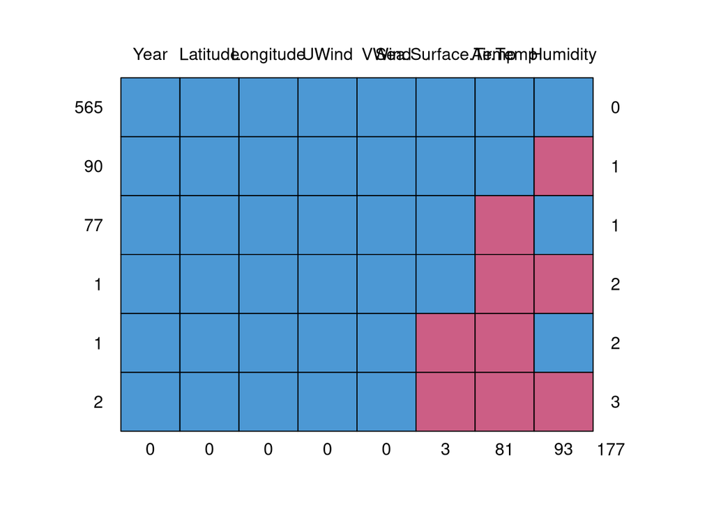

```
##     Year Latitude Longitude UWind VWind Sea.Surface.Temp Air.Temp Humidity
## 565    1        1         1     1     1                1        1        1   0
## 90     1        1         1     1     1                1        1        0   1
## 77     1        1         1     1     1                1        0        1   1
## 1      1        1         1     1     1                1        0        0   2
## 1      1        1         1     1     1                0        0        1   2
## 2      1        1         1     1     1                0        0        0   3
##        0        0         0     0     0                3       81       93 177
```

```r
library(mice)
md.pattern(tao)
```

## III. REALIZAR IMPUTACIONES

En este segundo caso la comparación no puede realizarse de la misma manera que se realiza en el caso 1, porque aquí los valores faltantes preexisten, es decir, no aparecen artificialmente como resultado de una introducción de los mismos por parte del usuario.

Así, el poder predictivo podría evaluarse viendo cómo las diferentes formas de imputación de la variable de interés se desempeñan en la predicción de una variable dependiente o de respuesta. Lo más lógico teóricamente es que dicha variable de respuesta sea la velocidad del viento ($VWind$). Sin embargo, en el curso no se realiza esto. Habrá que incorporarlo en algún momento.

### II.I. ELIMINAR REGISTROS DE VARIABLE

```r
lm(UWind ~ Sea.Surface.Temp, data=tao, na.action=na.omit)
```

```
##
## Call:
## lm(formula = UWind ~ Sea.Surface.Temp, data = tao, na.action = na.omit)
##
## Coefficients:
##      (Intercept)  Sea.Surface.Temp
##         -4.95708           0.04821
```

```r
lm(VWind ~ Sea.Surface.Temp, data=tao, na.action=na.omit)
```

```
##
## Call:
## lm(formula = VWind ~ Sea.Surface.Temp, data = tao, na.action = na.omit)
##
## Coefficients:
##      (Intercept)  Sea.Surface.Temp
##          4.76582          -0.08225
```

### II.II. IMPUTACIÓN CON MEDIDAS DE TENDENCIA CENTRAL

```r
library(Hmisc)

impute(tao$Sea.Surface.Temp,mean)
```

[output not shown]

[output cut: 129 more lines]

[output not shown]

```r
impute(tao$Sea.Surface.Temp,median)
```

[output not shown]

[output cut: 79 more lines]

[output not shown]

### II.III. IMPUTACIÓN POR PARTICIÓN RECURSIVA Y ÁRBOLES DE REGRESIÓN

```r
library(rpart)

#Estimación de Air Temp
anova_mod <- rpart(Air.Temp ~ . - VWind, data=tao[!is.na(tao$Air.Temp),], method="anova", na.action=na.omit)
Air.temp_pred<-predict(anova_mod, tao[is.na(tao$Air.Temp), ])
Air.temp_pred
```

```
##      108      109      110      111      112      113      114      115
## 27.29208 27.29208 27.29208 27.29208 26.13891 26.13891 26.13891 27.29208
##      116      117      118      119      120      121      122      123
## 27.29208 27.29208 27.29208 27.29208 27.29208 27.29208 27.29208 27.29208
##      124      125      126      127      128      129      130      131
## 27.29208 27.29208 27.29208 27.29208 27.29208 27.29208 27.29208 27.29208
##      132      133      134      135      136      137      138      139
## 27.29208 27.29208 27.29208 27.29208 27.29208 27.29208 27.29208 27.29208
##      140      141      142      143      144      145      146      147
## 27.29208 27.29208 27.29208 27.29208 27.29208 27.29208 27.29208 27.29208
##      148      149      150      151      152      153      154      155
## 27.29208 27.29208 27.29208 27.29208 27.29208 27.29208 27.29208 27.29208
##      156      157      158      159      160      161      162      163
## 27.29208 27.29208 27.29208 27.29208 27.29208 27.29208 27.29208 27.29208
##      164      165      166      167      168      169      170      171
## 27.29208 27.29208 27.29208 27.29208 27.29208 27.29208 27.29208 27.29208
##      172      173      174      175      176      177      178      179
## 27.29208 27.29208 27.29208 27.29208 27.29208 27.29208 27.29208 27.29208
##      180      181      182      183      184      460      463      481
## 27.29208 27.29208 27.29208 27.29208 27.29208 24.09847 22.93940 22.93940
##      637
## 24.09847
```

```r
#Estimación de Humidity
anova_mod <- rpart(Humidity ~ . - VWind, data=tao[!is.na(tao$Humidity),], method="anova", na.action=na.omit)
Humidity_pred <-predict(anova_mod, tao[is.na(tao$Humidity), ])
Humidity_pred
```

```
##      460      461      462      463      464      465      466      467
## 88.19464 86.51102 88.19464 84.38776 84.38776 84.38776 84.38776 86.51102
##      468      469      470      471      472      473      474      475
## 86.51102 86.51102 86.51102 86.51102 86.51102 86.51102 86.51102 86.51102
##      476      477      478      479      480      481      482      483
## 86.51102 84.38776 86.51102 84.38776 84.38776 84.38776 86.51102 86.51102
##      484      485      486      487      488      489      490      491
## 86.51102 86.51102 86.51102 86.51102 86.51102 86.51102 86.51102 86.51102
##      492      493      494      495      496      497      498      499
## 84.38776 84.38776 86.51102 86.51102 86.51102 86.51102 86.51102 86.51102
##      500      501      502      503      504      505      506      507
## 86.51102 86.51102 86.51102 86.51102 86.51102 86.51102 86.51102 86.51102
##      508      509      510      511      512      513      514      515
## 86.51102 86.51102 86.51102 86.51102 86.51102 86.51102 86.51102 86.51102
##      516      517      518      519      520      521      522      523
## 86.51102 88.19464 88.19464 88.19464 88.19464 88.19464 88.19464 88.19464
##      524      525      526      527      528      529      530      531
## 88.19464 88.19464 84.38776 84.38776 88.19464 88.19464 88.19464 88.19464
##      532      533      534      535      536      537      538      539
## 88.19464 88.19464 88.19464 86.51102 86.51102 88.19464 88.19464 88.19464
##      540      541      542      543      544      545      546      547
## 88.19464 88.19464 88.19464 84.38776 84.38776 84.38776 84.38776 84.38776
##      548      549      550      551      552
## 88.19464 88.19464 88.19464 88.19464 88.19464
```

### II.IV. IMPUTACIÓN MULTIVARIANTE CON ECUACIONES ENCADENADAS VÍA BOSQUES ALEATORIOS

```r
library(mice)

miceMod <- mice(tao[, !names(tao) %in% "VWind"], method="rf")
miceOutput <- complete(miceMod)
anyNA(miceOutput)
```

```
## [1] FALSE
```

```r
miceOutput
```

```
##     Year Latitude Longitude Sea.Surface.Temp Air.Temp Humidity UWind
## 1   1997        0      -110            27.59    27.15     79.6  -6.4
## 2   1997        0      -110            27.55    27.02     75.8  -5.3
## 3   1997        0      -110            27.57    27.00     76.5  -5.1
## 4   1997        0      -110            27.62    26.93     76.2  -4.9
## 5   1997        0      -110            27.65    26.84     76.4  -3.5
## 6   1997        0      -110            27.83    26.94     76.7  -4.4
## 7   1997        0      -110            28.01    27.04     76.5  -2.0
## 8   1997        0      -110            28.04    27.11     78.3  -3.7
## 9   1997        0      -110            28.02    27.21     78.6  -4.2
## 10  1997        0      -110            28.05    27.25     76.9  -3.6
## 11  1997        0      -110            28.07    27.23     77.6  -3.7
## 12  1997        0      -110            28.09    27.32     77.5  -4.8
## 13  1997        0      -110            28.20    27.31     80.1  -3.5
## 14  1997        0      -110            28.25    26.44     85.2  -1.0
```

[output cut: 722 more lines]